# Assignment- ML Role

PART A. Train a Classifier to classify stress companies vs non-stress companies. Use Yahoo Finance to collect Financial data for Indian companies (min 100 companies). Convert financial variables into features based on the following ratios. Current ratio Debt to equity ratio ROI (Return on investment) ROA (Return on assets) Inventory turnover ratio. Net profit margin Perform EDA(exploratory data analysis) on features. Label the data using the logic given below: A company is called in stress when its revenue to expenses ratio is less than 1. Train a machine learning classifier(Logistic regression, support vector machine, naive bays, decision tree ) to predict the classes and get the correlation of coefficients (weights) with respect to the degree of stress. Use the ensemble model to predict the final degree of stress. Evaluate the model on test data with evaluation matrices.

# Use Yahoo Finance to collect Financial data for Indian companies (min 100 companies).

```python
import pandas as pd
import matplotlib.pyplot as plt
import numpy as np
from numpy import NaN
from glob import glob
import re
import time
from datetime import datetime
import lxml
from lxml import html
import requests


pd.set_option('max_columns', 200)
pd.set_option('max_rows', 300)
pd.set_option('display.expand_frame_repr', True)
```

```python
def get_page(url):
    # Set up the request headers that we're going to use, to simulate
    # a request by the Chrome browser. Simulating a request from a browser
    # is generally good practice when building a scraper
    headers = {
        'Accept': 'text/html,application/xhtml+xml,application/xml;q=0.9,image/webp,image/apng,*/*;q=0.8,application/signed-exchange;v=b3',
        'Accept-Encoding': 'gzip, deflate, br',
        'Accept-Language': 'en-US,en;q=0.9',
        'Cache-Control': 'max-age=0',
        'Pragma': 'no-cache',
        'Referrer': 'https://google.com',
        'User-Agent': 'Mozilla/5.0 (Windows NT 10.0; Win64; x64) AppleWebKit/537.36 (KHTML, like Gecko) Chrome/77.0.3865.120 Safari/537.36'
    }

    return requests.get(url, headers=headers)

def parse_rows(table_rows):
    parsed_rows = []

    for table_row in table_rows:
        parsed_row = []
        el = table_row.xpath("./div")

        none_count = 0

        for rs in el:
            try:
                (text,) = rs.xpath('.//span/text()[1]')
                parsed_row.append(text)
            except ValueError:
                parsed_row.append(np.NaN)
                none_count += 1

        if (none_count < 2):
            parsed_rows.append(parsed_row)

    return pd.DataFrame(parsed_rows)

def clean_data(df):
    df = df.set_index(0) # Set the index to the first column: 'Period Ending'.
    df = df.transpose() # Transpose the DataFrame, so that our header contains the account names

    # Rename the "Breakdown" column to "Date"
    cols = list(df.columns)
    cols[0] = 'Date'
    df = df.set_axis(cols, axis='columns', inplace=False)

    numeric_columns = list(df.columns)[1::] # Take all columns, except the first (which is the 'Date' column)

    for column_index in range(1, len(df.columns)): # Take all columns, except the first (which is the 'Date' column)
        df.iloc[:,column_index] = df.iloc[:,column_index].str.replace(',', '') # Remove the thousands separator
        df.iloc[:,column_index] = df.iloc[:,column_index].astype(np.float64) # Convert the column to float64

    return df
```

```python
#getting data from tables
def scrape_table(url):

    # Fetch the page that we're going to parse
    page = get_page(url);

    # Parse the page with LXML, so that we can start doing some XPATH queries
    # to extract the data that we want
    tree = html.fromstring(page.content)
    time.sleep(5)
    # Fetch all div elements which have class 'D(tbr)'
    table_rows = tree.xpath("//div[contains(@class, 'D(tbr)')]")
    time.sleep(5)
    # Ensure that some table rows are found; if none are found, then it's possible
    # that Yahoo Finance has changed their page layout, or have detected
    # that you're scraping the page.
    assert  len(table_rows) > 0
    time.sleep(5)
    df = parse_rows(table_rows)
    df = clean_data(df)
    time.sleep(5)

    return df
```

```python
#geting data of multiple compines
def scrape(symbol):
    print('Attempting to scrape data for ' + symbol)

    df_balance_sheet = scrape_table('https://finance.yahoo.com/quote/' + symbol + '/balance-sheet?p=' + symbol)
    df_balance_sheet = df_balance_sheet.set_index('Date')

    df_income_statement = scrape_table('https://finance.yahoo.com/quote/' + symbol + '/financials?p=' + symbol)
    df_income_statement = df_income_statement.set_index('Date')

    df_cash_flow = scrape_table('https://finance.yahoo.com/quote/' + symbol + '/cash-flow?p=' + symbol)
    df_cash_flow = df_cash_flow.set_index('Date')

    df_joined = df_balance_sheet \
        .join(df_income_statement, on='Date', how='outer', rsuffix=' - Income Statement') \
        .join(df_cash_flow, on='Date', how='outer', rsuffix=' - Cash Flow') \
        .dropna(axis=1, how='all') \
        .reset_index()

    df_joined.insert(1, 'Symbol', symbol)

    return df_joined
```

```python
def scrape_multi(symbols):
    return pd.concat([scrape(symbol) for symbol in symbols], sort=False)
```

```python
#geeting only syombols of the compines

from bs4 import BeautifulSoup
import requests
list=[]
url='https://in.finance.yahoo.com/most-active?count=100&offset=100'
header = {
	'User-Agent': 'Mozilla/5.0 (Macintosh; Intel Mac OS X 10_11_2) AppleWebKit/601.3.9 (KHTML, like Gecko) Version/9.0.2 Safari/601.3.9'
}
response=requests.get(url,headers=header)
soup=BeautifulSoup(response.content, 'lxml')
for item in soup.select('.simpTblRow'):

	#print(item.select('[aria-label=Symbol]')[0].get_text())
    list1.append((item.select('[aria-label=Symbol]')[0].get_text()))
    #print('____________________________')
```

```python
df_combine = scrape_multi(list)
```

```python
#saving scarpped data from yahoo finance
date = datetime.today().strftime('%Y-%m-%d')
writer = pd.ExcelWriter('df8.xlsx')
df_combine.to_excel(writer)
writer.save()
```

```python
#importing required libraries
import os
import pandas as pd
cwd = os.path.abspath('')
files = os.listdir(cwd)
```

```python
cd C:\Users\harsha.teja\Desktop\solvedo\data
```

```
C:\Users\harsha.teja\Desktop\solvedo\data
```

```python
#loading the data
df_total = pd.DataFrame()
for file in files:                         # loop through Excel files
    if file.endswith('.xlsx'):
        excel_file = pd.ExcelFile(file)
        sheets = excel_file.sheet_names
        for sheet in sheets:               # loop through sheets inside an Excel file
            df = excel_file.parse(sheet_name = sheet)
            df_total = df_total.append(df)
df_total.to_excel('combined_file.xlsx')
```

```python
data = pd.read_excel('combined_file.xlsx')
```

```python
data.shape
```

```
(549, 65)
```

```python
data
```

|  | Unnamed: 0 | Unnamed: 0.1 | index | Symbol | Date | Total Assets | Total Liabilities Net Minority Interest | Total Equity Gross Minority Interest | Total Capitalization | Common Stock Equity | Net Tangible Assets | Working Capital | Invested Capital | Tangible Book Value | Total Debt | Net Debt | Share Issued | Ordinary Shares Number | Total Revenue | Cost of Revenue | Gross Profit | Operating Expense | Operating Income | Net Non Operating Interest Income Expense | Pretax Income | Tax Provision | Net Income Common Stockholders | Diluted NI Available to Com Stockholders | Basic Average Shares | … |
| --- | --- | --- | --- | --- | --- | --- | --- | --- | --- | --- | --- | --- | --- | --- | --- | --- | --- | --- | --- | --- | --- | --- | --- | --- | --- | --- | --- | --- | --- | --- |
| 0 | 0 | 0 | 3/31/2020 | SANWARIA.NS | 3/31/2020 | 3719967.0 | 9382262.0 | -5662295.0 | -5582520.0 | -5662295.0 | -5662295.0 | -6611568.0 | 3313684.0 | -5662295.0 | 8975979.0 | 8967485.0 | 736100.0 | 736100.0 | 28647986.0 | 31405862.0 | -2757876.0 | 483395.0 | -3241271.0 | -9339.0 | -12205779.0 | -9538.0 | -12196240.0 | -12196240.0 | 736100.0 | … |
| 1 | 1 | 1 | 3/31/2019 | SANWARIA.NS | 3/31/2019 | 17949803.0 | 11438281.0 | 6511522.0 | 7179322.0 | 6511522.0 | 6511522.0 | 5856057.0 | 16294940.0 | 6511522.0 | 9783418.0 | 9768560.0 | 736100.0 | 736100.0 | 53037911.0 | 49302099.0 | 3735812.0 | 1090927.0 | 2644885.0 | -711519.0 | 1952520.0 | 391953.0 | 1560567.0 | 1560567.0 | 736100.0 | … |
| 2 | 2 | 2 | 3/31/2018 | SANWARIA.NS | 3/31/2018 | 17316959.0 | 11375655.0 | 5941304.0 | 6128227.0 | 5941304.0 | 5941304.0 | 4758320.0 | 15849744.0 | 5941304.0 | 9908440.0 | 9887966.0 | 736100.0 | 736100.0 | 50547302.0 | 47679275.0 | 2868028.0 | 685630.0 | 2182397.0 | -715337.0 | 1165018.0 | 318161.0 | 846857.0 | 846857.0 | 736100.0 | … |
| 3 | 3 | 3 | NaN | SANWARIA.NS | ttm | NaN | NaN | NaN | NaN | NaN | NaN | NaN | NaN | NaN | NaN | NaN | NaN | NaN | -21949074.0 | -21770479.0 | -178595.0 | -6559145.0 | 6380550.0 | 748603.0 | -2148930.0 | -9538.0 | -2139391.0 | -2139391.0 | NaN | … |
| 4 | 4 | 0 | 3/31/2020 | EDELWEISS.NS | 3/31/2020 | 542803210.0 | 470732440.0 | 72070770.0 | 422061470.0 | 61287110.0 | 56987110.0 | NaN | 422061470.0 | 56987110.0 | 360774360.0 | 315972240.0 | 934409.0 | 934409.0 | 38965920.0 | NaN | NaN | NaN | NaN | NaN | -24566520.0 | -4128800.0 | -20452450.0 | -20452450.0 | 888713.0 | … |
| ... | ... | ... | ... | ... | ... | ... | ... | ... | ... | ... | ... | ... | ... | ... | ... | ... | ... | ... | ... | ... | ... | ... | ... | ... | ... | ... | ... | ... | ... | … |
| 544 | 107 | 3 | NaN | MRPL.NS | ttm | NaN | NaN | NaN | NaN | NaN | NaN | NaN | NaN | NaN | NaN | NaN | NaN | NaN | 324543340.0 | 338641060.0 | -14097720.0 | 14402510.0 | -28500230.0 | -2082850.0 | -42709340.0 | -10217350.0 | -27091880.0 | -27091880.0 | NaN | … |
| 545 | 108 | 0 | 3/31/2020 | GODREJCP.NS | 3/31/2020 | 149570100.0 | 70586500.0 | 78983600.0 | 100434000.0 | 78983600.0 | -773900.0 | 2617800.0 | 114167100.0 | -773900.0 | 35749700.0 | 29154800.0 | 1022316.0 | 1022316.0 | 99108000.0 | 45390200.0 | 53717800.0 | 34070600.0 | 19647200.0 | -1518800.0 | 17604000.0 | 2638200.0 | 14965800.0 | 14965800.0 | 1022266.0 | … |
| 546 | 109 | 1 | 3/31/2019 | GODREJCP.NS | 3/31/2019 | 141700800.0 | 69031600.0 | 72669200.0 | 98717000.0 | 72669200.0 | -2122100.0 | 7966300.0 | 106489700.0 | -2122100.0 | 33820500.0 | 25198400.0 | 1022166.0 | 1022166.0 | 103143400.0 | 48119700.0 | 55023700.0 | 35184400.0 | 19839300.0 | -1514500.0 | 20853300.0 | -2562000.0 | 23415300.0 | 23415300.0 | 1022111.0 | … |
| 547 | 110 | 2 | 3/31/2018 | GODREJCP.NS | 3/31/2018 | 139627100.0 | 77044000.0 | 62583100.0 | 86386300.0 | 62583100.0 | -9921300.0 | 10028800.0 | 97520600.0 | -9921300.0 | 34937500.0 | 25957300.0 | 1021994.0 | 1021994.0 | 97680200.0 | 45150300.0 | 52529900.0 | 32892100.0 | 19637800.0 | -1046200.0 | 20388800.0 | 4047000.0 | 16341800.0 | 16341800.0 | 1021928.0 | … |
| 548 | 111 | 3 | NaN | GODREJCP.NS | ttm | NaN | NaN | NaN | NaN | NaN | NaN | NaN | NaN | NaN | NaN | NaN | NaN | NaN | 104516800.0 | 49088600.0 | 55428200.0 | 33817800.0 | 21610400.0 | -997000.0 | 19933400.0 | 4084600.0 | 15848800.0 | 15848800.0 | NaN | … |

549 rows × 65 columns

```python
data.info()
```

```
<class 'pandas.core.frame.DataFrame'>
RangeIndex: 549 entries, 0 to 548
Data columns (total 65 columns):
 #   Column                                                      Non-Null Count  Dtype
---  ------                                                      --------------  -----
 0   Unnamed: 0                                                  549 non-null    int64
 1   Unnamed: 0.1                                                549 non-null    int64
 2   index                                                       409 non-null    object
 3   Symbol                                                      549 non-null    object
 4   Date                                                        549 non-null    object
 5   Total Assets                                                409 non-null    float64
 6   Total Liabilities Net Minority Interest                     409 non-null    float64
 7   Total Equity Gross Minority Interest                        409 non-null    float64
 8   Total Capitalization                                        409 non-null    float64
 9   Common Stock Equity                                         409 non-null    float64
```

[output cut: 57 more lines]

```python
#fillter only required data
final_data = data[data['Date']=='3/31/2020']
```

```python
len(final_data)
```

```
127
```

```python
final_data.shape
```

```
(127, 65)
```

```python
final_data.columns
```

```
Index(['Unnamed: 0', 'Unnamed: 0.1', 'index', 'Symbol', 'Date', 'Total Assets',
       'Total Liabilities Net Minority Interest',
       'Total Equity Gross Minority Interest', 'Total Capitalization',
       'Common Stock Equity', 'Net Tangible Assets', 'Working Capital',
       'Invested Capital', 'Tangible Book Value', 'Total Debt', 'Net Debt',
       'Share Issued', 'Ordinary Shares Number', 'Total Revenue',
       'Cost of Revenue', 'Gross Profit', 'Operating Expense',
       'Operating Income', 'Net Non Operating Interest Income Expense',
       'Pretax Income', 'Tax Provision', 'Net Income Common Stockholders',
       'Diluted NI Available to Com Stockholders', 'Basic Average Shares',
       'Diluted Average Shares', 'Rent Expense Supplemental', 'Total Expenses',
       'Net Income from Continuing & Discontinued Operation',
       'Normalized Income', 'Interest Income', 'Interest Expense',
       'Net Interest Income', 'EBIT', 'Reconciled Cost of Revenue',
       'Reconciled Depreciation',
       'Net Income from Continuing Operation Net Minority Interest',
       'Total Unusual Items Excluding Goodwill', 'Total Unusual Items',
       'Normalized EBITDA', 'Tax Rate for Calcs',
       'Tax Effect of Unusual Items', 'Operating Cash Flow',
       'Investing Cash Flow', 'Financing Cash Flow', 'End Cash Position',
       'Issuance of Debt', 'Repayment of Debt', 'Free Cash Flow',
       'Preferred Stock Equity',
       'Income from Associates & Other Participating Interests',
       'Special Income Charges', 'Capital Expenditure',
       'Capital Lease Obligations', 'Issuance of Capital Stock',
       'Repurchase of Capital Stock', 'Other Income Expense',
       'Treasury Shares Number', 'Non Interest Expense',
       'INTEREST_INCOME_AFTER_PROVISION_FOR_LOAN_LOSS',
       'Total Money Market Investments'],
      dtype='object')
```

```python
final_data=final_data.reset_index()
```

```python
#Current Ratio= Current assets/Current liabilities
```

```python
final_data['current ratio'] = final_data['Total Assets']/final_data['Total Liabilities Net Minority Interest']
```

```python
#Debt-To-Equity Ratio (D/E) Formula and Calculation
#Debt/Equity= Total Liabilities/Total Shareholders’ Equity
#working_capital = current_assets - current_liabilities
```

```python
final_data['working_capital'] = final_data['Total Assets']  - final_data['Total Liabilities Net Minority Interest']
```

```python
final_data['Net icome'] = final_data['Total Revenue']  - final_data['Total Expenses']
```

```python
#firt need to calcalte the net income
#net inome = totltevenves - total expense
final_data['Net icome'] = final_data['Total Revenue']  - final_data['Total Expenses']
```

```python
final_data['Debt to equity ratio'] = final_data['Total Liabilities Net Minority Interest']/final_data['Total Equity Gross Minority Interest']
```

```python
#ROA (Return on assets) =Net income or total revens/ total assets
```

```python
final_data['Return on assets'] = final_data['Net icome'] /final_data['Total Assets']
```

```python
#ROI (Return on investment) = net income/cost of investment
```

```python
final_data['Return on investment'] = final_data['Net icome'] /final_data['Cost of Revenue']
```

```python
# revenue to expenses ratio = operting expense/operting income
```

```python
final_data['revenue to expenses ratio'] = final_data['Operating Expense']/final_data['Operating Income']
```

```python
#Net profit margin = netprofit/totalrevene *100

final_data['Net profit margin'] = (final_data['Net icome']/final_data['Total Revenue'])*100
```

```python
#Inventory turnover ratio= Total revenve/Average inventory
final_data['Average inventory'] = (final_data['Operating Cash Flow']+final_data['End Cash Position'])/2
final_data['Inventory turnover ratio'] = final_data['Operating Expense']/final_data['Average inventory']
```

```python
final_data.isnull().sum()
```

```
level_0                                                         0
Unnamed: 0                                                      0
Unnamed: 0.1                                                    0
index                                                           0
Symbol                                                          0
Date                                                            0
Total Assets                                                    0
Total Liabilities Net Minority Interest                         0
Total Equity Gross Minority Interest                            0
Total Capitalization                                            0
Common Stock Equity                                             0
Net Tangible Assets                                             0
Working Capital                                                15
Invested Capital                                                0
Tangible Book Value                                             0
Total Debt                                                      7
Net Debt                                                       36
Share Issued                                                    0
Ordinary Shares Number                                          0
Total Revenue                                                   0
Cost of Revenue                                                18
Gross Profit                                                   18
Operating Expense                                              15
Operating Income                                               15
Net Non Operating Interest Income Expense                      15
Pretax Income                                                   0
Tax Provision                                                   3
Net Income Common Stockholders                                  0
Diluted NI Available to Com Stockholders                        0
Basic Average Shares                                           17
Diluted Average Shares                                         17
Rent Expense Supplemental                                      39
Total Expenses                                                 15
Net Income from Continuing & Discontinued Operation             0
Normalized Income                                               0
Interest Income                                                34
Interest Expense                                               19
Net Interest Income                                            15
EBIT                                                           15
Reconciled Cost of Revenue                                     18
```

[output cut: 19 more lines]

```
Issuance of Capital Stock                                      91
Repurchase of Capital Stock                                   120
Other Income Expense                                          125
Treasury Shares Number                                        126
Non Interest Expense                                          126
INTEREST_INCOME_AFTER_PROVISION_FOR_LOAN_LOSS                 126
Total Money Market Investments                                126
current ratio                                                   0
Net icome                                                      15
Debt to equity ratio                                            0
Return on assets                                               15
Return on investment                                           18
Net profit margin                                              15
revenue to expenses ratio                                      15
dtype: int64
```

```python
final_data.shape
```

```
(127, 72)
```

# Selecting only reuired fetures as given in satament

```python
final_data1 = final_data[['Symbol','Debt to equity ratio', 'Net icome','Return on assets','Return on investment','Net profit margin','Inventory turnover ratio','revenue to expenses ratio']]
```

```python
final_data1.head()
```

|  | Symbol | Debt to equity ratio | Net icome | Return on assets | Return on investment | Net profit margin | Inventory turnover ratio | revenue to expenses ratio |
| --- | --- | --- | --- | --- | --- | --- | --- | --- |
| 0 | SANWARIA.NS | -1.656972 | -3241270.0 | -0.871317 | -0.103206 | -11.314129 | 1.870033 | -0.149137 |
| 1 | EDELWEISS.NS | 6.531531 | NaN | NaN | NaN | NaN | NaN | NaN |
| 2 | PANACEABIO.NS | 6.102463 | 420600.0 | 0.030252 | 0.240929 | 7.829690 | 65.767747 | 7.621303 |
| 3 | BHARATFORG.NS | 1.201720 | 6016260.0 | 0.052031 | 0.128149 | 7.843789 | 2.587769 | 3.945511 |
| 4 | POWERGRID.BO | 2.967105 | 210452300.0 | 0.081999 | 18.399236 | 57.176861 | 0.814825 | 0.694609 |

```python
#checking for null values
final_data1.isnull().sum()
```

```
Symbol                        0
Debt to equity ratio          0
Net icome                    15
Return on assets             15
Return on investment         18
Net profit margin            15
Inventory turnover ratio     15
revenue to expenses ratio    15
dtype: int64
```

```python
final_data1 = final_data1.dropna()
```

```python
final_data1.shape
```

```
(109, 8)
```

```python
final_data1.head()
```

|  | Symbol | Debt to equity ratio | Net icome | Return on assets | Return on investment | Net profit margin | Inventory turnover ratio | revenue to expenses ratio |
| --- | --- | --- | --- | --- | --- | --- | --- | --- |
| 0 | SANWARIA.NS | -1.656972 | -3241270.0 | -0.871317 | -0.103206 | -11.314129 | 1.870033 | -0.149137 |
| 2 | PANACEABIO.NS | 6.102463 | 420600.0 | 0.030252 | 0.240929 | 7.829690 | 65.767747 | 7.621303 |
| 3 | BHARATFORG.NS | 1.201720 | 6016260.0 | 0.052031 | 0.128149 | 7.843789 | 2.587769 | 3.945511 |
| 4 | POWERGRID.BO | 2.967105 | 210452300.0 | 0.081999 | 18.399236 | 57.176861 | 0.814825 | 0.694609 |
| 5 | SADHNANIQ.BO | 0.853189 | 241674.0 | 0.112062 | 0.577615 | 23.503497 | -3.596641 | 1.523424 |

```python
len(final_data1)
```

```
109
```

```python
final_data1['stress_nonstress'] = final_data1['revenue to expenses ratio'].apply(lambda x: 1 if x > 1  else 0)
```

```python
final_data1['stress_nonstress'].value_counts()
```

```
1    65
0    44
Name: stress_nonstress, dtype: int64
```

```python
final_data1.head()
```

|  | Symbol | Debt to equity ratio | Net icome | Return on assets | Return on investment | Net profit margin | Inventory turnover ratio | revenue to expenses ratio | stress_nonstress |
| --- | --- | --- | --- | --- | --- | --- | --- | --- | --- |
| 0 | SANWARIA.NS | -1.656972 | -3241270.0 | -0.871317 | -0.103206 | -11.314129 | 1.870033 | -0.149137 | 0 |
| 2 | PANACEABIO.NS | 6.102463 | 420600.0 | 0.030252 | 0.240929 | 7.829690 | 65.767747 | 7.621303 | 1 |
| 3 | BHARATFORG.NS | 1.201720 | 6016260.0 | 0.052031 | 0.128149 | 7.843789 | 2.587769 | 3.945511 | 1 |
| 4 | POWERGRID.BO | 2.967105 | 210452300.0 | 0.081999 | 18.399236 | 57.176861 | 0.814825 | 0.694609 | 0 |
| 5 | SADHNANIQ.BO | 0.853189 | 241674.0 | 0.112062 | 0.577615 | 23.503497 | -3.596641 | 1.523424 | 1 |

# Perform EDA(exploratory data analysis) on features.

```python
# importing data science modules
import pandas as pd
import numpy as np
import sklearn
from sklearn import preprocessing
import scipy as sp
import pickleshare

# importing graphics modules
import matplotlib.pyplot as plt
import seaborn as sns
from scipy.stats import norm
from matplotlib.gridspec import GridSpec
cols= ['#00876c','#85b96f','#f7e382','#f19452','#d43d51']


from sklearn.model_selection import KFold
import matplotlib.pyplot as plt
import warnings
warnings.filterwarnings('ignore')
%matplotlib inline
import os
pd.set_option('display.max_columns', 999)
pd.set_option('display.max_rows', 999)
pd.set_option('display.width', 1000)

import sklearn
import datetime

from sklearn.pipeline import make_pipeline
from sklearn.preprocessing import StandardScaler

from sklearn.metrics import accuracy_score
from sklearn.linear_model import LogisticRegression
from sklearn.tree import DecisionTreeClassifier
from sklearn.pipeline import Pipeline
import pickle

from IPython.display import display
import plotly.offline as py
import plotly.graph_objs as go
import plotly.tools as tls
py.init_notebook_mode(connected=True)
from IPython.display import display
%matplotlib inline
```

```python
final_data1.info()
```

```
<class 'pandas.core.frame.DataFrame'>
Int64Index: 109 entries, 0 to 126
Data columns (total 9 columns):
 #   Column                     Non-Null Count  Dtype
---  ------                     --------------  -----
 0   Symbol                     109 non-null    object
 1   Debt to equity ratio       109 non-null    float64
 2   Net icome                  109 non-null    float64
 3   Return on assets           109 non-null    float64
 4   Return on investment       109 non-null    float64
 5   Net profit margin          109 non-null    float64
 6   Inventory turnover ratio   109 non-null    float64
 7   revenue to expenses ratio  109 non-null    float64
 8   stress_nonstress           109 non-null    int64
dtypes: float64(7), int64(1), object(1)
memory usage: 8.5+ KB
```

```python
final_data1.describe().T
```

|  | count | mean | std | min | 25% | 50% | 75% | max |
| --- | --- | --- | --- | --- | --- | --- | --- | --- |
| Debt to equity ratio | 109.0 | 1.575573e+00 | 5.147112e+00 | -3.943854e+01 | 0.372121 | 1.160758e+00 | 2.424977e+00 | 2.024188e+01 |
| Net icome | 109.0 | 1.036073e+07 | 6.000763e+07 | -2.014225e+08 | 140592.000000 | 1.070692e+06 | 5.635030e+06 | 4.113440e+08 |
| Return on assets | 109.0 | 4.051842e-02 | 1.915265e-01 | -1.582324e+00 | 0.018001 | 6.817086e-02 | 1.002260e-01 | 2.197050e-01 |
| Return on investment | 109.0 | 5.800518e-01 | 2.771235e+00 | -5.218623e+00 | 0.027191 | 1.306793e-01 | 3.599843e-01 | 1.839924e+01 |
| Net profit margin | 109.0 | 1.113119e+01 | 2.487822e+01 | -1.390515e+02 | 2.582241 | 8.849290e+00 | 1.695224e+01 | 1.093420e+02 |
| Inventory turnover ratio | 109.0 | -9.829045e-01 | 4.013564e+01 | -3.826648e+02 | 0.814825 | 2.540624e+00 | 5.528720e+00 | 6.576775e+01 |
| revenue to expenses ratio | 109.0 | 1.079265e+01 | 7.940555e+01 | -1.514637e+02 | 0.459976 | 1.523424e+00 | 3.128317e+00 | 7.742514e+02 |
| stress_nonstress | 109.0 | 5.963303e-01 | 4.928989e-01 | 0.000000e+00 | 0.000000 | 1.000000e+00 | 1.000000e+00 | 1.000000e+00 |

```python
#for correlation
final_data1.corr()
```

|  | Debt to equity ratio | Net icome | Return on assets | Return on investment | Net profit margin | Inventory turnover ratio | revenue to expenses ratio | stress_nonstress |
| --- | --- | --- | --- | --- | --- | --- | --- | --- |
| Debt to equity ratio | 1.000000 | 0.007882 | 0.074236 | 0.053508 | 0.109415 | 0.092486 | 0.054622 | 0.077439 |
| Net icome | 0.007882 | 1.000000 | 0.103501 | 0.428963 | 0.214035 | 0.039120 | -0.013582 | 0.113890 |
| Return on assets | 0.074236 | 0.103501 | 1.000000 | 0.101120 | 0.447520 | 0.064113 | -0.017708 | 0.223541 |
| Return on investment | 0.053508 | 0.428963 | 0.101120 | 1.000000 | 0.326503 | 0.183994 | -0.020590 | -0.089710 |
| Net profit margin | 0.109415 | 0.214035 | 0.447520 | 0.326503 | 1.000000 | 0.083193 | -0.047469 | -0.068199 |
| Inventory turnover ratio | 0.092486 | 0.039120 | 0.064113 | 0.183994 | 0.083193 | 1.000000 | 0.016718 | 0.121025 |
| revenue to expenses ratio | 0.054622 | -0.013582 | -0.017708 | -0.020590 | -0.047469 | 0.016718 | 1.000000 | 0.171239 |
| stress_nonstress | 0.077439 | 0.113890 | 0.223541 | -0.089710 | -0.068199 | 0.121025 | 0.171239 | 1.000000 |

```python
 correlation =final_data1.corr()
```

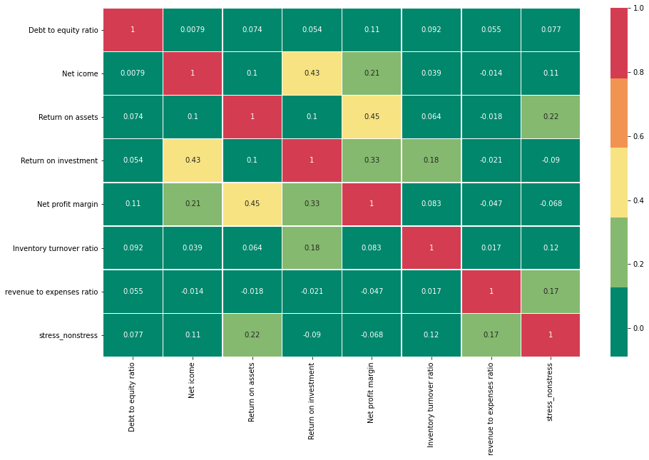

```python
plt.figure(figsize=(15,9))
sns.heatmap(correlation,cmap=cols, annot=True, linewidths=0.5)
plt.show()
```

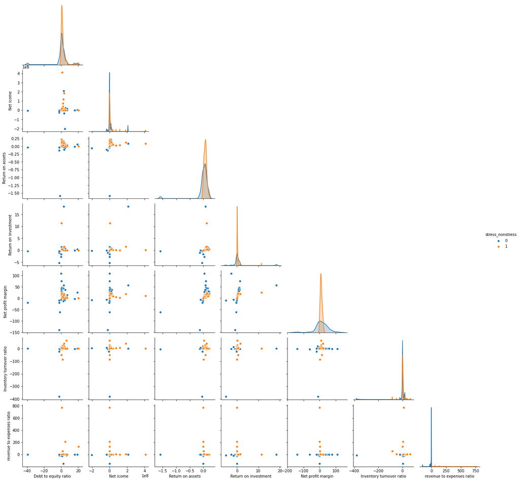

```python
#pair plot
sns.pairplot(final_data1[1:], hue='stress_nonstress',corner=True)
```

```python
#distrubution of data
def disbution_of_data(feture):
    plt.figure(figsize=(15,9))
    sns.distplot(feture,color='green',bins=100)
```

```python
final_data1.columns
```

```
Index(['Symbol', 'Debt to equity ratio', 'Net icome', 'Return on assets',
       'Return on investment', 'Net profit margin', 'Inventory turnover ratio',
       'revenue to expenses ratio', 'stress_nonstress'],
      dtype='object')
```

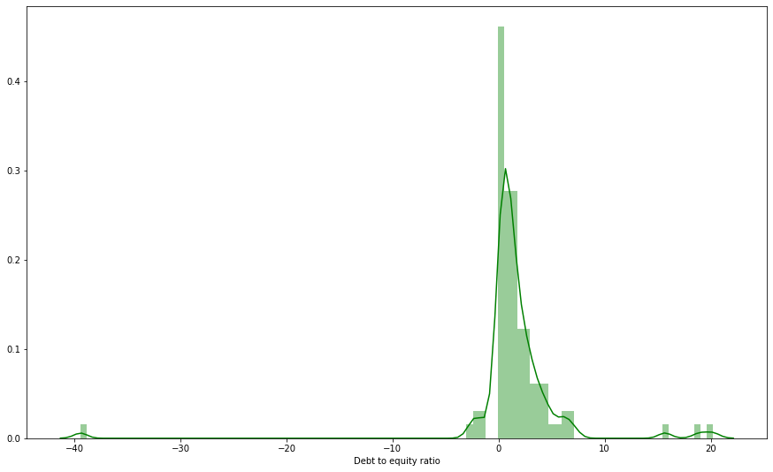

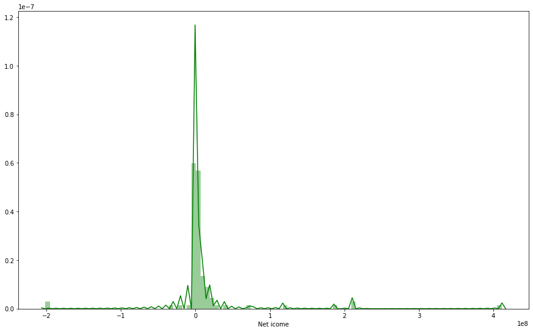

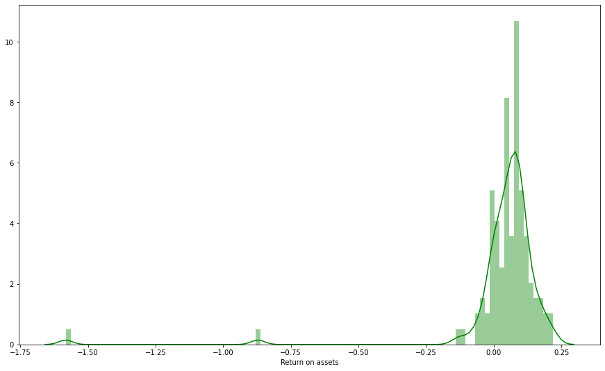

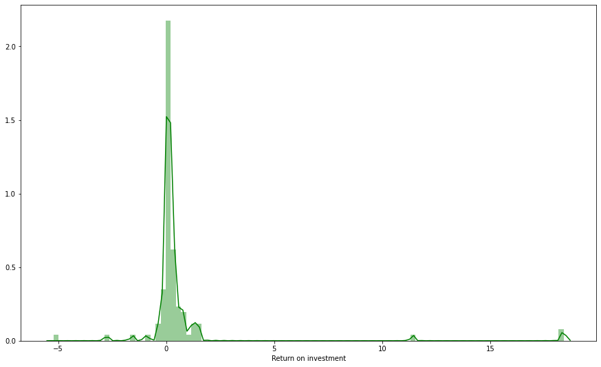

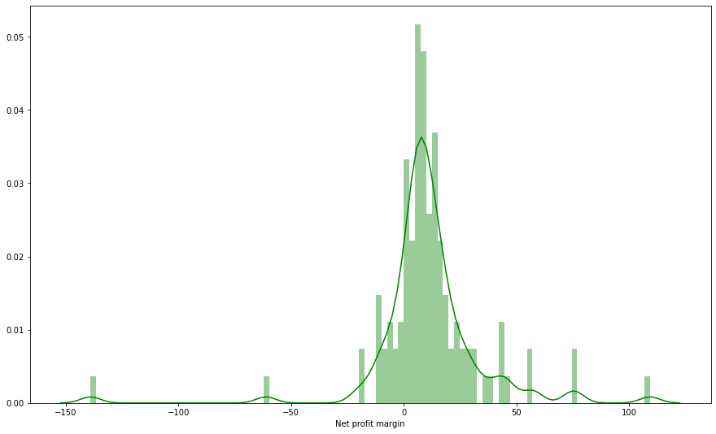

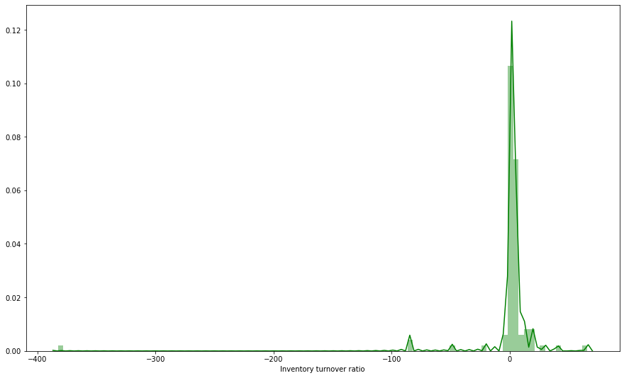

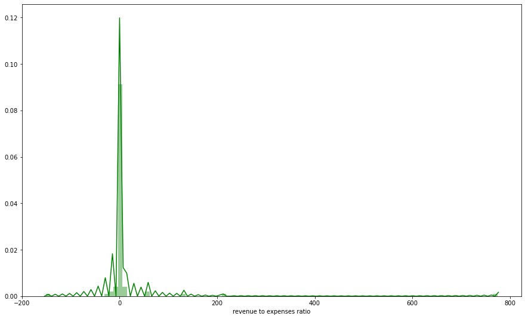

```python
disbution_of_data(final_data1['Debt to equity ratio'])
disbution_of_data(final_data1['Net icome'])
disbution_of_data(final_data1['Return on assets'])
disbution_of_data(final_data1['Return on investment'])
disbution_of_data(final_data1['Net profit margin'])
disbution_of_data(final_data1['Inventory turnover ratio'])
disbution_of_data(final_data1['revenue to expenses ratio'])
```

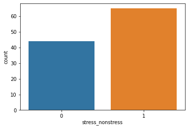

```python
#countin of class feture
sns.countplot(final_data1['stress_nonstress'])
```

Univariate Analysis The objective of univariate analysis is to examine each of the variables one by one. The focus will be on the distribution of the variable. Let's start with dependent variable.

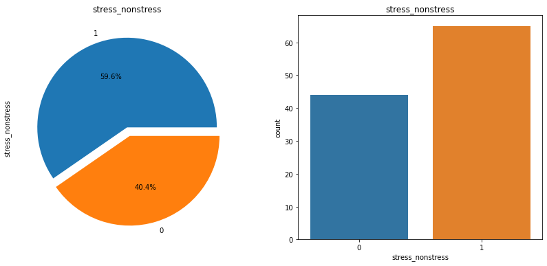

```python
f,ax=plt.subplots(1,2,figsize=(14,6))
final_data1['stress_nonstress'].value_counts().plot.pie(explode=[0,0.1],autopct='%1.1f%%',ax=ax[0],shadow=False)
ax[0].set_title('stress_nonstress')
ax[0].set_ylabel('stress_nonstress')
sns.countplot('stress_nonstress',data=final_data1,ax=ax[1])
ax[1].set_title('stress_nonstress')
plt.show()
```

```python
final_data1.columns
```

```
Index(['Symbol', 'Debt to equity ratio', 'Net icome', 'Return on assets',
       'Return on investment', 'Net profit margin', 'Inventory turnover ratio',
       'revenue to expenses ratio', 'stress_nonstress'],
      dtype='object')
```

```python
columns = ['Debt to equity ratio', 'Net icome', 'Return on assets',
       'Return on investment', 'Net profit margin', 'Inventory turnover ratio',
       'revenue to expenses ratio', 'stress_nonstress']
```

```
Debt to equity ratio
```

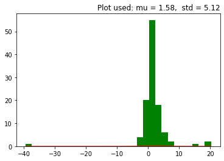

```
Net icome
```

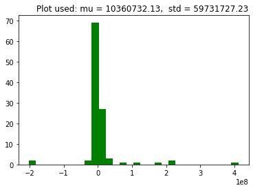

```
Return on assets
```

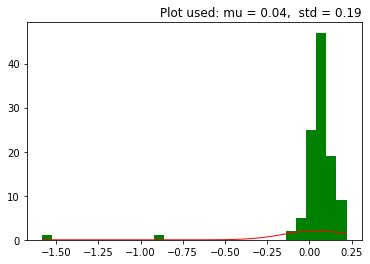

```
Return on investment
```

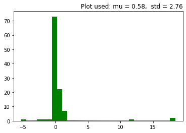

```
Net profit margin
```

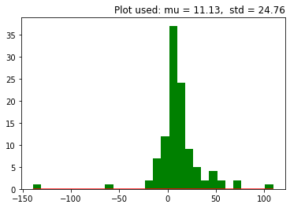

```
Inventory turnover ratio
```

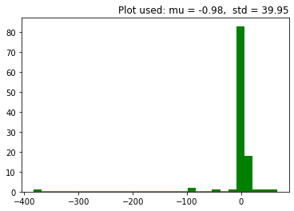

```
revenue to expenses ratio
```

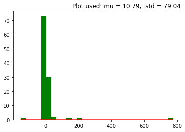

```
stress_nonstress
```

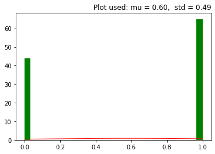

```python
for column in columns:
    print(column)
    #s=df['column']
    s=final_data1[column]
    mu, sigma =norm.fit(s)
    count, bins, ignored = plt.hist(s, 30, color='g')
    plt.plot(bins, 1/(sigma * np.sqrt(2 * np.pi)) *np.exp( - (bins - mu)**2 / (2 * sigma**2) ), linewidth=1, color='r')

    title = "Plot used: mu = %.2f,  std = %.2f" % (mu, sigma)
    plt.title(title, loc='right')

    plt.show()
```

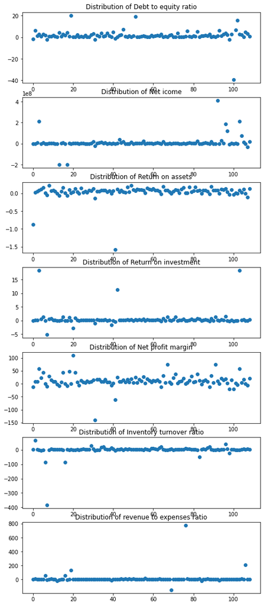

```python
cols_to_use = ['Debt to equity ratio', 'Net icome', 'Return on assets',
       'Return on investment', 'Net profit margin', 'Inventory turnover ratio',
       'revenue to expenses ratio']
fig = plt.figure(figsize=(8, 20))
plot_count = 0
for col in cols_to_use:
    plot_count += 1
    plt.subplot(7, 1, plot_count)
    plt.scatter(range(final_data1.shape[0]), final_data1[col].values)
    plt.title("Distribution of "+col)
plt.show()
```

```python
columns = ['Debt to equity ratio', 'Net icome', 'Return on assets',
       'Return on investment', 'Net profit margin', 'Inventory turnover ratio',
       'revenue to expenses ratio', 'stress_nonstress']
```

```python
df_name=final_data1.columns
```

```python
def OutLiersBox(df,nameOfFeature):

    trace0 = go.Box(
        y = df[nameOfFeature],
        name = "All Points",
        jitter = 0.3,
        pointpos = -1.8,
        boxpoints = 'all',
        marker = dict(
            color = 'rgb(7,40,89)'),
        line = dict(
            color = 'rgb(7,40,89)')
    )

    trace1 = go.Box(
        y = df[nameOfFeature],
        name = "Only Whiskers",
        boxpoints = False,
        marker = dict(
            color = 'rgb(9,56,125)'),
        line = dict(
            color = 'rgb(9,56,125)')
    )

    trace2 = go.Box(
        y = df[nameOfFeature],
        name = "Suspected Outliers",
        boxpoints = 'suspectedoutliers',
        marker = dict(
            color = 'rgb(8,81,156)',
            outliercolor = 'rgba(219, 64, 82, 0.6)',
            line = dict(
                outliercolor = 'rgba(219, 64, 82, 0.6)',
                outlierwidth = 2)),
        line = dict(
            color = 'rgb(8,81,156)')
    )

    trace3 = go.Box(
        y = df[nameOfFeature],
        name = "Whiskers and Outliers",
        boxpoints = 'outliers',
        marker = dict(
            color = 'rgb(107,174,214)'),
        line = dict(
            color = 'rgb(107,174,214)')
    )

    data = [trace0,trace1,trace2,trace3]

    layout = go.Layout(
        title = "{} Outliers".format(nameOfFeature)
    )

    fig = go.Figure(data=data,layout=layout)
    py.iplot(fig, filename = "Outliers")
```

```python
#outliners investgation
```

```python
OutLiersBox(final_data1,df_name[1])
```

[interactive chart not shown]

```python
OutLiersBox(final_data1,df_name[2])
```

[interactive chart not shown]

```python
OutLiersBox(final_data1,df_name[3])
```

[interactive chart not shown]

```python
OutLiersBox(final_data1,df_name[4])
```

[interactive chart not shown]

```python
OutLiersBox(final_data1,df_name[5])
```

[interactive chart not shown]

```python
OutLiersBox(final_data1,df_name[6])
```

[interactive chart not shown]

```python
OutLiersBox(final_data1,df_name[7])
```

[interactive chart not shown]

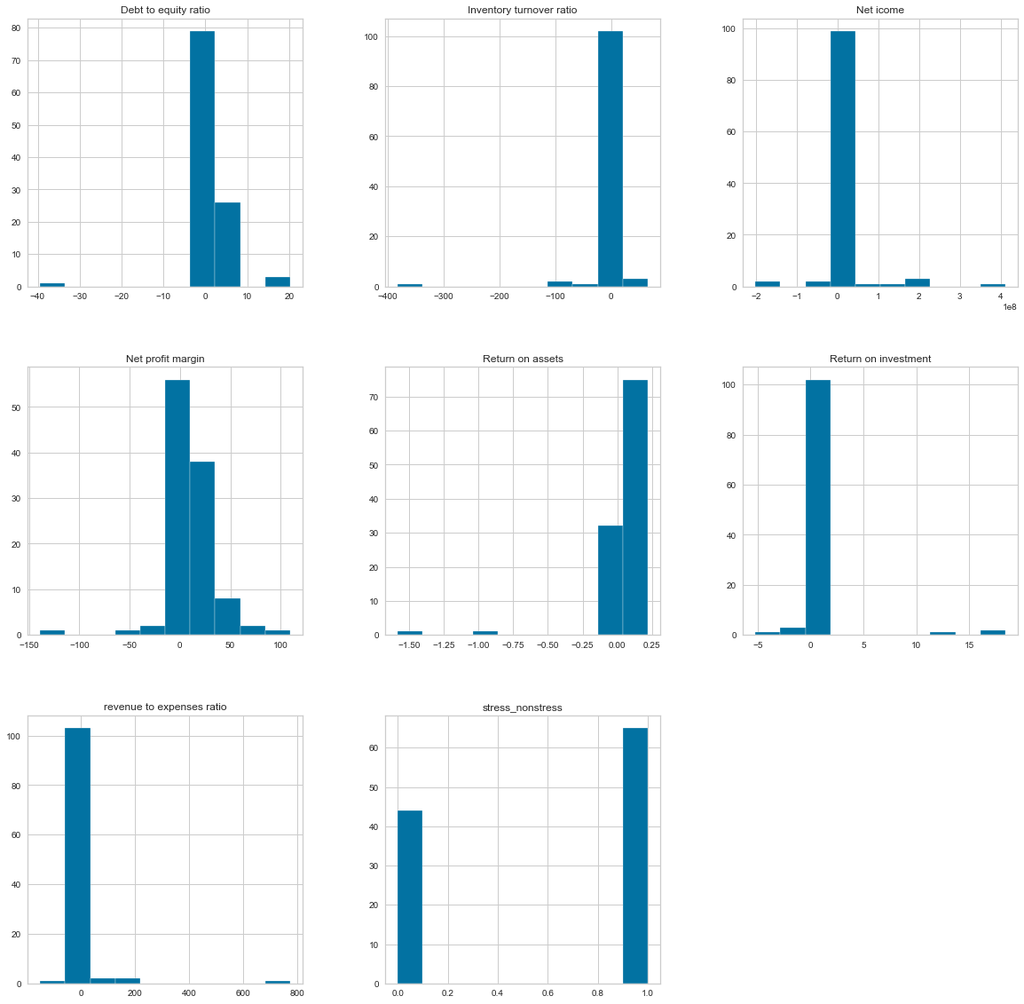

```python
#histogram of all fetures
p =final_data1.hist(figsize = (20,20))
```

```python
#fininding the feture importance using XGboost
import xgboost as xgb

train_y = final_data1['stress_nonstress']
train_X = final_data1.drop(['Symbol','stress_nonstress'], axis=1)

xgb_params = {
    'eta': 0.05,
    'max_depth': 10,
    'subsample': 1.0,
    'colsample_bytree': 0.7,
    'objective': 'reg:linear',
    'eval_metric': 'rmse',
    'silent': 1
}
```

[output not shown]

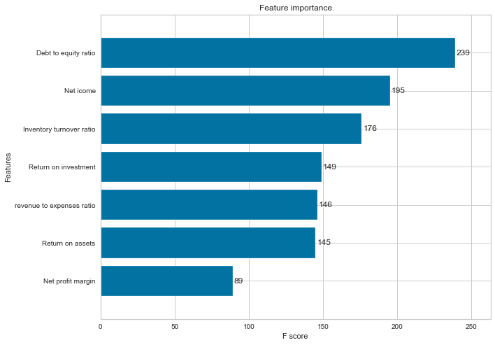

```python
import warnings
warnings.filterwarnings('ignore')
dtrain = xgb.DMatrix(train_X, train_y, feature_names=train_X.columns.values)
model = xgb.train(dict(xgb_params, silent=0), dtrain, num_boost_round=100)
remain_num = 99

fig, ax = plt.subplots(figsize=(10,8))
xgb.plot_importance(model, max_num_features=remain_num, height=0.8, ax=ax)
plt.show()
```